# Microarray Pipeline

Mehdi Merbah

9/18/2020

This is an R Markdown of the Bioconductor packages setup through BiocManager.

## Loading Packages

We load the required packages for the workflow.

```r
suppressPackageStartupMessages({library("maEndToEnd")})
```

```r
#General Bioconductor packages
    library(Biobase)
    library(oligoClasses)

#Annotation and data import packages
    library(ArrayExpress)
    library(pd.hugene.1.0.st.v1)
    library(hugene10sttranscriptcluster.db)

#Quality control and pre-processing packages
    library(oligo)
    library(arrayQualityMetrics)

#Analysis and statistics packages
    library(limma)
    library(topGO)
    library(ReactomePA)
    library(clusterProfiler)

#Plotting and color options packages
    library(gplots)
    library(ggplot2)
    library(geneplotter)
    library(RColorBrewer)
    library(pheatmap)

#Formatting/documentation packages
   #library(rmarkdown)
   #library(BiocStyle)
    library(dplyr)
    library(tidyr)

#Helpers:
    library(stringr)
    library(matrixStats)
    library(genefilter)
    library(openxlsx)
   #library(devtools)
```

## Loading ArrayExpress Data

We downloaded Array Express data to a local directory and are loading it from there.

```r
sdrf_location <- file.path(raw_data_dir, "E-MTAB-2967.sdrf.txt")
SDRF <- read.delim(sdrf_location)

rownames(SDRF) <- SDRF$Array.Data.File
SDRF <- AnnotatedDataFrame(SDRF)

raw_data <- oligo::read.celfiles(filenames = file.path(raw_data_dir, SDRF$Array.Data.File), verbose = FALSE, phenoData = SDRF)
```

[output not shown]

[output cut: 20 more lines]

```r
stopifnot(validObject(raw_data))
```

## Exploring the Data

```r
head(Biobase::pData(raw_data))
```

```
##             Source.Name Characteristics.individual. Characteristics.organism.
## 164_I_.CEL        164_I                         164              Homo sapiens
## 164_II.CEL       164_II                         164              Homo sapiens
## 183_I.CEL         183_I                         183              Homo sapiens
## 183_II.CEL       183_II                         183              Homo sapiens
## 2114_I.CEL       2114_I                        2114              Homo sapiens
## 2114_II.CEL     2114_II                        2114              Homo sapiens
##             Characteristics.disease. Characteristics.organism.part.
## 164_I_.CEL           Crohn's disease                          colon
## 164_II.CEL           Crohn's disease                          colon
## 183_I.CEL            Crohn's disease                          colon
## 183_II.CEL           Crohn's disease                          colon
## 2114_I.CEL           Crohn's disease                          colon
## 2114_II.CEL          Crohn's disease                          colon
##              Characteristics.phenotype. Material.Type Protocol.REF
## 164_I_.CEL  non-inflamed colonic mucosa organism part P-MTAB-41361
## 164_II.CEL      inflamed colonic mucosa organism part P-MTAB-41361
## 183_I.CEL   non-inflamed colonic mucosa organism part P-MTAB-41361
## 183_II.CEL      inflamed colonic mucosa organism part P-MTAB-41361
## 2114_I.CEL  non-inflamed colonic mucosa organism part P-MTAB-41361
## 2114_II.CEL     inflamed colonic mucosa organism part P-MTAB-41361
##             Protocol.REF.1 Extract.Name Protocol.REF.2 Labeled.Extract.Name
## 164_I_.CEL    P-MTAB-41363        164_I   P-MTAB-41364         164_I:Biotin
## 164_II.CEL    P-MTAB-41363       164_II   P-MTAB-41364        164_II:Biotin
## 183_I.CEL     P-MTAB-41363        183_I   P-MTAB-41364         183_I:Biotin
## 183_II.CEL    P-MTAB-41363       183_II   P-MTAB-41364        183_II:Biotin
## 2114_I.CEL    P-MTAB-41363       2114_I   P-MTAB-41364        2114_I:Biotin
## 2114_II.CEL   P-MTAB-41363      2114_II   P-MTAB-41364       2114_II:Biotin
##               Label Protocol.REF.3 Assay.Name Technology.Type Array.Design.REF
## 164_I_.CEL  biotin    P-MTAB-41366     164_I_     array assay       A-AFFY-141
## 164_II.CEL  biotin    P-MTAB-41366     164_II     array assay       A-AFFY-141
## 183_I.CEL   biotin    P-MTAB-41366      183_I     array assay       A-AFFY-141
## 183_II.CEL  biotin    P-MTAB-41366     183_II     array assay       A-AFFY-141
## 2114_I.CEL  biotin    P-MTAB-41366     2114_I     array assay       A-AFFY-141
## 2114_II.CEL biotin    P-MTAB-41366    2114_II     array assay       A-AFFY-141
##             Term.Source.REF Protocol.REF.4 Array.Data.File
## 164_I_.CEL     ArrayExpress   P-MTAB-41367      164_I_.CEL
## 164_II.CEL     ArrayExpress   P-MTAB-41367      164_II.CEL
## 183_I.CEL      ArrayExpress   P-MTAB-41367       183_I.CEL
## 183_II.CEL     ArrayExpress   P-MTAB-41367      183_II.CEL
## 2114_I.CEL     ArrayExpress   P-MTAB-41367      2114_I.CEL
## 2114_II.CEL    ArrayExpress   P-MTAB-41367     2114_II.CEL
##                                                                                 Comment..ArrayExpress.FTP.file.
## 164_I_.CEL  ftp://ftp.ebi.ac.uk/pub/databases/microarray/data/experiment/MTAB/E-MTAB-2967/E-MTAB-2967.raw.1.zip
## 164_II.CEL  ftp://ftp.ebi.ac.uk/pub/databases/microarray/data/experiment/MTAB/E-MTAB-2967/E-MTAB-2967.raw.1.zip
## 183_I.CEL   ftp://ftp.ebi.ac.uk/pub/databases/microarray/data/experiment/MTAB/E-MTAB-2967/E-MTAB-2967.raw.1.zip
## 183_II.CEL  ftp://ftp.ebi.ac.uk/pub/databases/microarray/data/experiment/MTAB/E-MTAB-2967/E-MTAB-2967.raw.1.zip
## 2114_I.CEL  ftp://ftp.ebi.ac.uk/pub/databases/microarray/data/experiment/MTAB/E-MTAB-2967/E-MTAB-2967.raw.1.zip
## 2114_II.CEL ftp://ftp.ebi.ac.uk/pub/databases/microarray/data/experiment/MTAB/E-MTAB-2967/E-MTAB-2967.raw.1.zip
##             Factor.Value.disease.     Factor.Value.phenotype.
## 164_I_.CEL        Crohn's disease non-inflamed colonic mucosa
## 164_II.CEL        Crohn's disease     inflamed colonic mucosa
## 183_I.CEL         Crohn's disease non-inflamed colonic mucosa
## 183_II.CEL        Crohn's disease     inflamed colonic mucosa
## 2114_I.CEL        Crohn's disease non-inflamed colonic mucosa
## 2114_II.CEL       Crohn's disease     inflamed colonic mucosa
```

```r
Biobase::pData(raw_data) <- Biobase::pData(raw_data)[, c("Source.Name","Characteristics.individual.",       "Factor.Value.disease.","Factor.Value.phenotype.")]
head(Biobase::pData(raw_data))
```

```
##             Source.Name Characteristics.individual. Factor.Value.disease.
## 164_I_.CEL        164_I                         164       Crohn's disease
## 164_II.CEL       164_II                         164       Crohn's disease
## 183_I.CEL         183_I                         183       Crohn's disease
## 183_II.CEL       183_II                         183       Crohn's disease
## 2114_I.CEL       2114_I                        2114       Crohn's disease
## 2114_II.CEL     2114_II                        2114       Crohn's disease
##                 Factor.Value.phenotype.
## 164_I_.CEL  non-inflamed colonic mucosa
## 164_II.CEL      inflamed colonic mucosa
## 183_I.CEL   non-inflamed colonic mucosa
## 183_II.CEL      inflamed colonic mucosa
## 2114_I.CEL  non-inflamed colonic mucosa
## 2114_II.CEL     inflamed colonic mucosa
```

## Quality Control of the data

After we have imported our raw data from the downloaded sets, the first thing we do is Quality Control (QC). The purpose of quality control is to check for any outliers and if our data clusters as we would expect it to based on the predefined experimental procedures and conditions. Here our rows represent individual probe intensities, while each column represents a single microarray. And so essentially we have 58 columns of both inflamed and non-inflamed mucosa.

```r
Biobase::exprs(raw_data)[1:3, 1:5]
```

```
##   164_I_.CEL 164_II.CEL 183_I.CEL 183_II.CEL 2114_I.CEL
## 1       4496       5310      4492       4511       2872
## 2        181        280       137        101         91
## 3       4556       5104      4379       4608       2972
```

For quality control purposes, expression data is commonly analyzed on a logarithmic scale.

```r
exp_raw <- log2(Biobase::exprs(raw_data))
```

### Principal Component Analysis

Here we perform a Principal Component Analysis (PCA) and generate a plot using the ggplot2 library .

Notice that we take transpose (using t() function) of the log2-transformed expression data, as the principal component function in R uses rows to indicate samples and columns to indicate variables (probe intensities in this case).

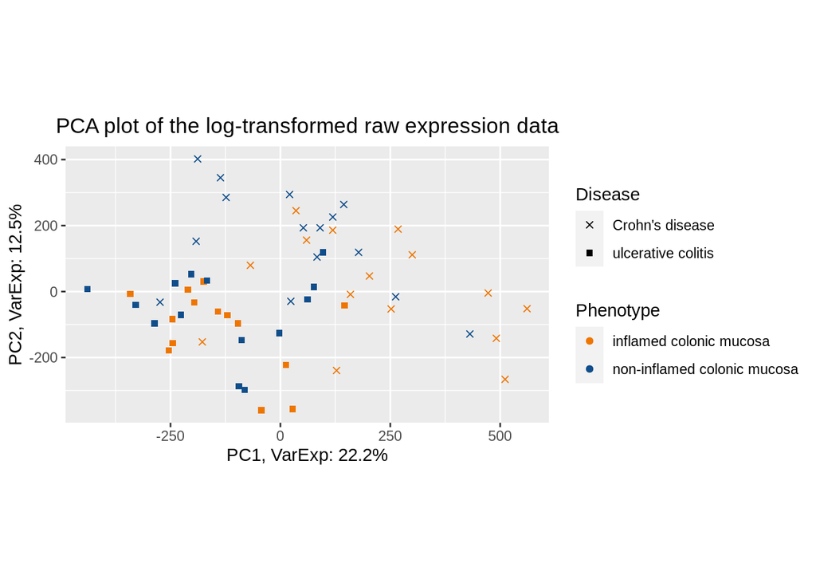

```r
PCA_raw <- prcomp(t(exp_raw), scale. = FALSE)

percentVar <- round(100*PCA_raw$sdev^2/sum(PCA_raw$sdev^2),1)
sd_ratio <- sqrt(percentVar[2] / percentVar[1])

dataGG <- data.frame(PC1 = PCA_raw$x[,1], PC2 = PCA_raw$x[,2],
                    Disease = pData(raw_data)$Factor.Value.disease.,
                    Phenotype = pData(raw_data)$Factor.Value.phenotype.,
                    Individual = pData(raw_data)$Characteristics.individual.)

ggplot(dataGG, aes(PC1, PC2)) +
      geom_point(aes(shape = Disease, colour = Phenotype)) +
  ggtitle("PCA plot of the log-transformed raw expression data") +
  xlab(paste0("PC1, VarExp: ", percentVar[1], "%")) +
  ylab(paste0("PC2, VarExp: ", percentVar[2], "%")) +
  theme(plot.title = element_text(hjust = 0.5))+
  coord_fixed(ratio = sd_ratio) +
  scale_shape_manual(values = c(4,15)) +
  scale_color_manual(values = c("darkorange2", "dodgerblue4"))
```

The colors in our plot represent the type of tissue (ie. Inflamed and non-inflamed) and the geo-labels represent the type of the disease for each sample.

We could say by analyzing the PCA plot that PC1 separates or differentiates between the disease types (Meaning that there are 2 clusters based on disease type along the first PC.)

This might affect our analysis since we are interested in DGE based on tissue phenotype and not disease type.

NOTE: It is more interesting to calculate the percent deviation for each principal component to see the percent contribution of each component to the overall variation in the data. Essentially the components are ranked in descending order of “Variability Contribution” and so the 2 most contributing components are PC1 and PC2.

The following barplot showcases this:

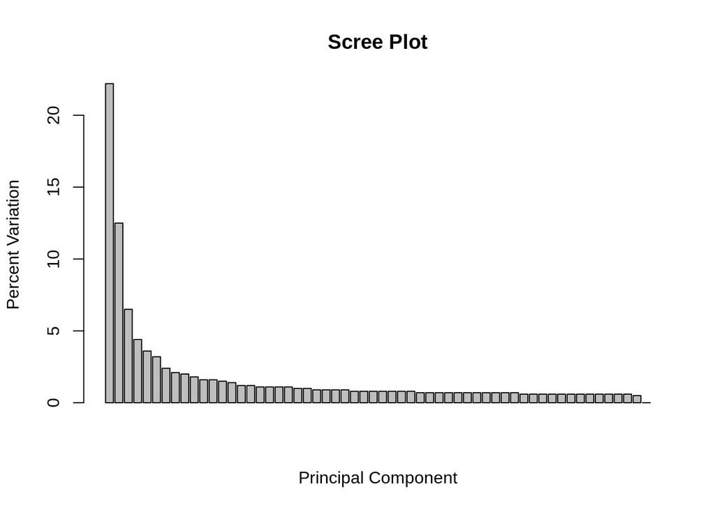

```r
barplot(percentVar, main ="Scree Plot", xlab = "Principal Component", ylab = "Percent Variation")
```

### Boxplot of log-transformed Data

We could represent our probe intensities with a boxplot, with one box for each microarray.

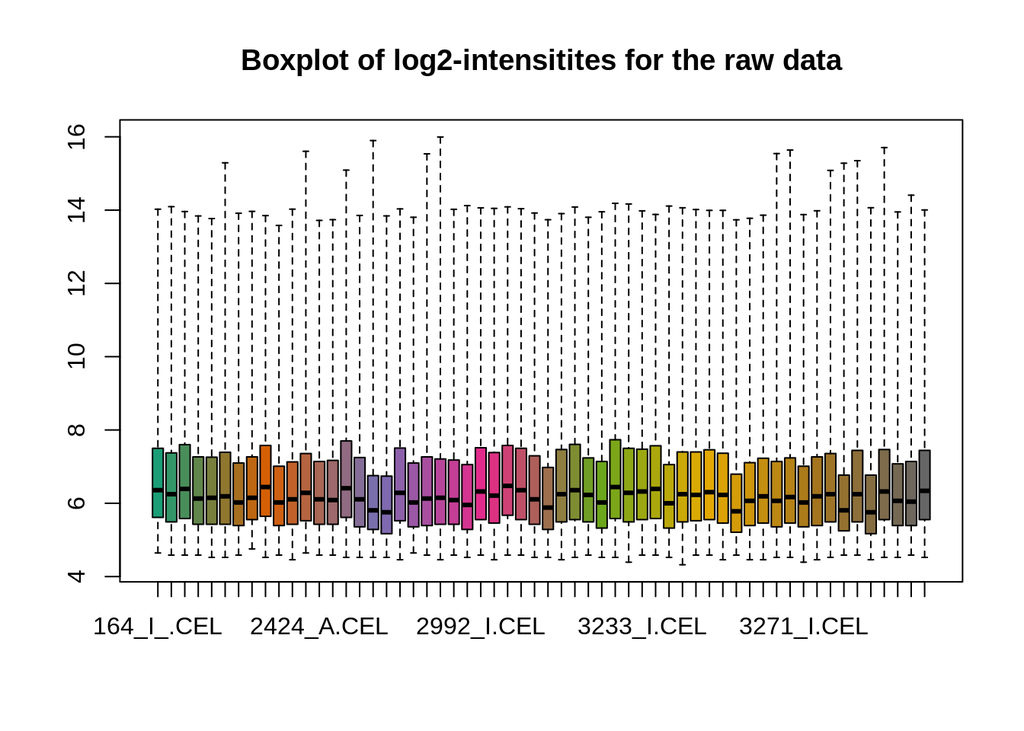

```r
oligo::boxplot(raw_data, target = "core",
               main = "Boxplot of log2-intensitites for the raw data")
```

Looking at the boxplots we can notice that the intensity distributions for individual arrays are very different and so we need to normalize them. Next section elaborates on normalization.

## Background adjustment, calibration and summarization

### Across-array normalization

### Summarization

```r
head(ls("package:hugene10sttranscriptcluster.db"))
```

```
## [1] "hugene10sttranscriptcluster"
## [2] "hugene10sttranscriptcluster_dbconn"
## [3] "hugene10sttranscriptcluster_dbfile"
## [4] "hugene10sttranscriptcluster_dbInfo"
## [5] "hugene10sttranscriptcluster_dbschema"
## [6] "hugene10sttranscriptcluster.db"
```

### Probesets: Old vs New

Difference between old and new Affymetrix array probesests.

NOTE: Newer microarray chips no longer have MM probes that were used for background correction. More elaborate techniques do not require such probes.

## Relative Log Expression data Quality Analysis

We perform an RMA without normalization

```r
palmieri_eset <- oligo::rma(raw_data, target = "core", normalize = FALSE)
```

```
## Background correcting
## Calculating Expression
```

### Relative Log Expression

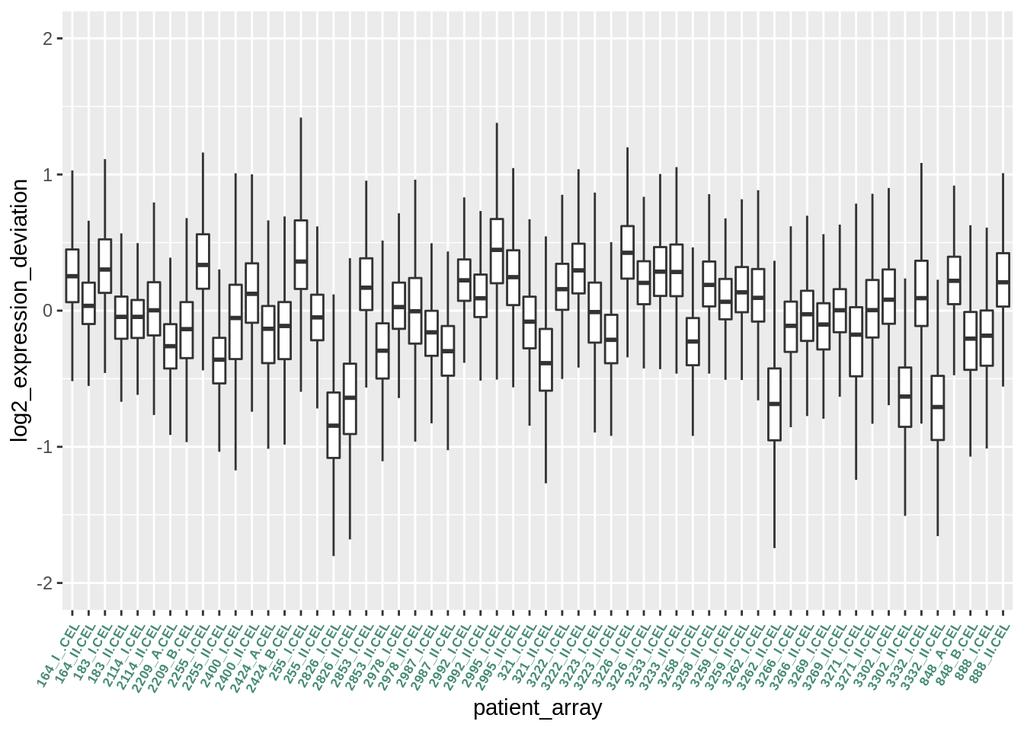

```r
row_medians_assayData <-
  Biobase::rowMedians(as.matrix(Biobase::exprs(palmieri_eset)))

RLE_data <- sweep(Biobase::exprs(palmieri_eset), 1, row_medians_assayData)

RLE_data <- as.data.frame(RLE_data)
RLE_data_gathered <-
  tidyr::gather(RLE_data, patient_array, log2_expression_deviation)

ggplot2::ggplot(RLE_data_gathered, aes(patient_array,
                                       log2_expression_deviation)) +
  geom_boxplot(outlier.shape = NA) +
  ylim(c(-2, 2)) +
  theme(axis.text.x = element_text(colour = "aquamarine4",
                                  angle = 60, size = 6.5, hjust = 1 ,
                                  face = "bold"))
```

## RMA Calibration

Now we run the full RMA Algorithm

```r
palmieri_eset_norm <- oligo::rma(raw_data, target = "core")
```

```
## Background correcting
## Normalizing
## Calculating Expression
```

### Quality Assesment of calibrated data using PCA

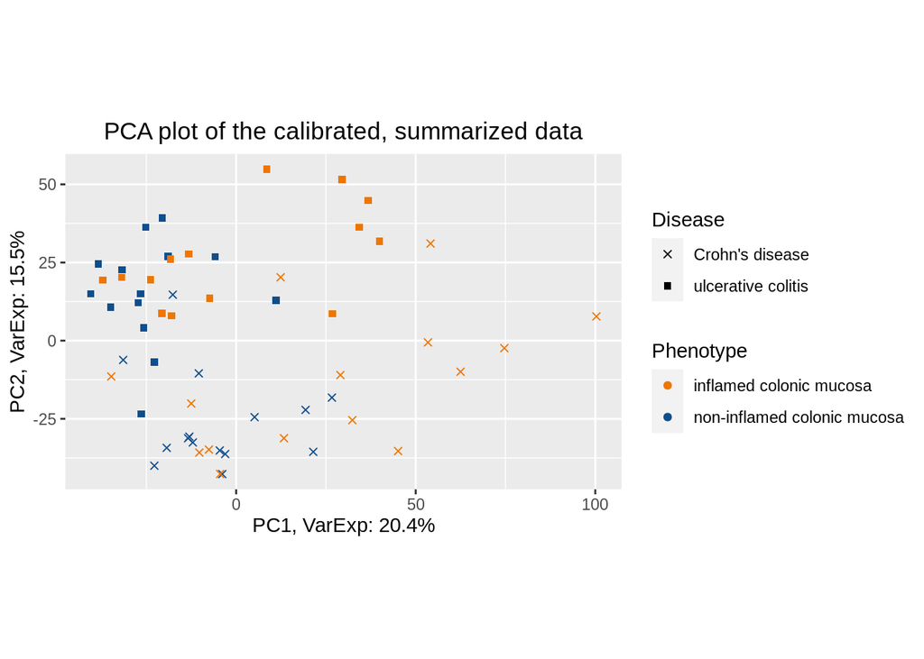

```r
exp_palmieri <- Biobase::exprs(palmieri_eset_norm)
PCA <- prcomp(t(exp_palmieri), scale = FALSE)

percentVar <- round(100*PCA$sdev^2/sum(PCA$sdev^2),1)
sd_ratio <- sqrt(percentVar[2] / percentVar[1])

dataGG <- data.frame(PC1 = PCA$x[,1], PC2 = PCA$x[,2],
                    Disease =
                     Biobase::pData(palmieri_eset_norm)$Factor.Value.disease.,
                    Phenotype =
                     Biobase::pData(palmieri_eset_norm)$Factor.Value.phenotype.)


ggplot(dataGG, aes(PC1, PC2)) +
      geom_point(aes(shape = Disease, colour = Phenotype)) +
  ggtitle("PCA plot of the calibrated, summarized data") +
  xlab(paste0("PC1, VarExp: ", percentVar[1], "%")) +
  ylab(paste0("PC2, VarExp: ", percentVar[2], "%")) +
  theme(plot.title = element_text(hjust = 0.5)) +
  coord_fixed(ratio = sd_ratio) +
  scale_shape_manual(values = c(4,15)) +
  scale_color_manual(values = c("darkorange2", "dodgerblue4"))
```

### Heatmap Clustering Analysis

We first set up the variables for the pheatmap function into a dataframe

```r
phenotype_names <- ifelse(str_detect(pData
                                    (palmieri_eset_norm)$Factor.Value.phenotype.,
                             "non"), "non_infl.", "infl.")

disease_names <- ifelse(str_detect(pData
                                    (palmieri_eset_norm)$Factor.Value.disease.,
                             "Crohn"), "CD", "UC")

annotation_for_heatmap <-
  data.frame(Phenotype = phenotype_names,  Disease = disease_names)

row.names(annotation_for_heatmap) <- row.names(pData(palmieri_eset_norm))
```

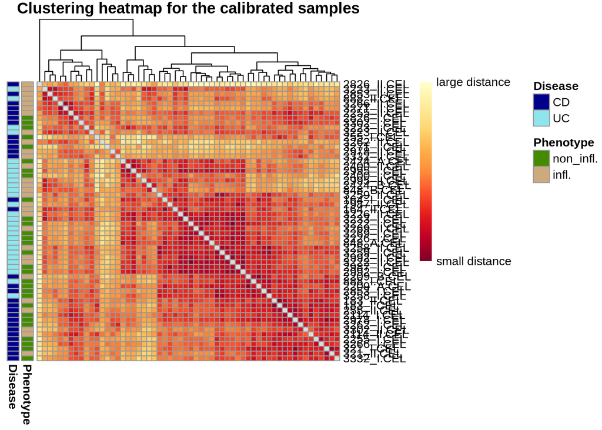

```r
dists <- as.matrix(dist(t(exp_palmieri), method = "manhattan"))

rownames(dists) <- row.names(pData(palmieri_eset_norm))
hmcol <- rev(colorRampPalette(RColorBrewer::brewer.pal(9, "YlOrRd"))(255))
colnames(dists) <- NULL
diag(dists) <- NA

ann_colors <- list(
  Phenotype = c(non_infl. = "chartreuse4", infl. = "burlywood3"),
  Disease = c(CD = "blue4", UC = "cadetblue2")
                   )
pheatmap(dists, col = (hmcol),
         annotation_row = annotation_for_heatmap,
         annotation_colors = ann_colors,
         legend = TRUE,
         treeheight_row = 0,
         legend_breaks = c(min(dists, na.rm = TRUE),
                         max(dists, na.rm = TRUE)),
         legend_labels = (c("small distance", "large distance")),
         main = "Clustering heatmap for the calibrated samples")
```

## Filtering Based on intensity

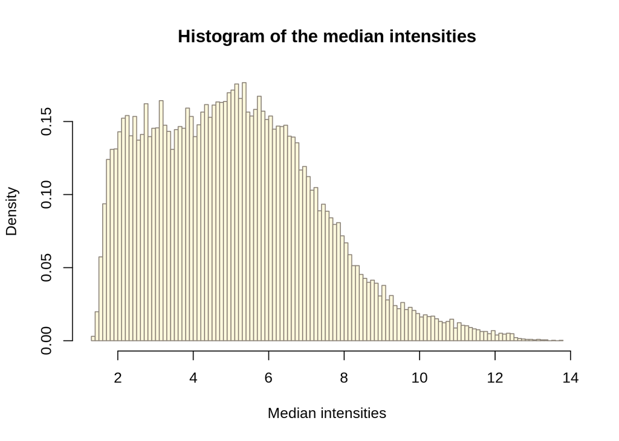

```r
palmieri_medians <- rowMedians(Biobase::exprs(palmieri_eset_norm))

hist_res <- hist(palmieri_medians, 100, col = "cornsilk1", freq = FALSE,
            main = "Histogram of the median intensities",
            border = "antiquewhite4",
            xlab = "Median intensities")
```

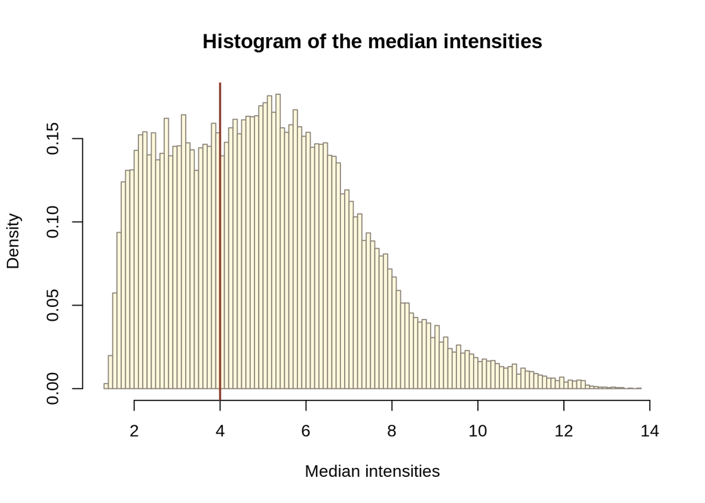

```r
man_threshold <- 4

hist_res <- hist(palmieri_medians, 100, col = "cornsilk", freq = FALSE,
            main = "Histogram of the median intensities",
            border = "antiquewhite4",
            xlab = "Median intensities")

abline(v = man_threshold, col = "coral4", lwd = 2)
```

```r
no_of_samples <-
  table(paste0(pData(palmieri_eset_norm)$Factor.Value.disease., "_",
                  pData(palmieri_eset_norm)$Factor.Value.phenotype.))
no_of_samples
```

```
##
##        Crohn's disease_inflamed colonic mucosa
##                                             15
##    Crohn's disease_non-inflamed colonic mucosa
##                                             15
##     ulcerative colitis_inflamed colonic mucosa
##                                             14
## ulcerative colitis_non-inflamed colonic mucosa
##                                             14
```

```r
samples_cutoff <- min(no_of_samples)

idx_man_threshold <- apply(Biobase::exprs(palmieri_eset_norm), 1,
                           function(x){
                          sum(x > man_threshold) >= samples_cutoff})
                          table(idx_man_threshold)
```

```
## idx_man_threshold
## FALSE  TRUE
## 10493 22804
```

```r
palmieri_manfiltered <- subset(palmieri_eset_norm, idx_man_threshold)
```

## Annotating Transcript Clusters

We add feature data to identify which transcript clusters refer to which genes.

```r
anno_palmieri <- AnnotationDbi::select(hugene10sttranscriptcluster.db,
                                  keys = (featureNames(palmieri_manfiltered)),
                                  columns = c("SYMBOL", "GENENAME"),
                                  keytype = "PROBEID")
anno_palmieri <- subset(anno_palmieri, !is.na(SYMBOL))
```

```r
anno_grouped <- group_by(anno_palmieri, PROBEID)
anno_summarized <-
  dplyr::summarize(anno_grouped, no_of_matches = n_distinct(SYMBOL))
head(anno_summarized)
```

```
## # A tibble: 6 x 2
##   PROBEID no_of_matches
##   <chr>           <int>
## 1 7896742             3
## 2 7896754             1
## 3 7896759             1
## 4 7896761             1
## 5 7896779             1
## 6 7896798             1
```

```r
anno_filtered <- filter(anno_summarized, no_of_matches > 1)

head(anno_filtered)
```

```
## # A tibble: 6 x 2
##   PROBEID no_of_matches
##   <chr>           <int>
## 1 7896742             3
## 2 7896937             3
## 3 7896961             3
## 4 7897006             2
## 5 7897632             3
## 6 7897774             2
```

```r
probe_stats <- anno_filtered

nrow(probe_stats)
```

```
## [1] 1753
```

```r
ids_to_exlude <- (featureNames(palmieri_manfiltered) %in% probe_stats$PROBEID)

table(ids_to_exlude)
```

```
## ids_to_exlude
## FALSE  TRUE
## 21051  1753
```

The final expression set is generated, one that doesn’t include the excluded identifiers:

```r
palmieri_final <- subset(palmieri_manfiltered, !ids_to_exlude)

validObject(palmieri_final)
```

```
## [1] TRUE
```

```r
head(anno_palmieri)
```

```
##      PROBEID       SYMBOL
## 2657 7896742  LINC00266-1
## 2658 7896742       PCMTD2
## 2659 7896742    LINC01881
## 2664 7896754 LOC100287497
## 2665 7896759    LINC01128
## 2666 7896761       SAMD11
##                                                                          GENENAME
## 2657                                 long intergenic non-protein coding RNA 266-1
## 2658 protein-L-isoaspartate (D-aspartate) O-methyltransferase domain containing 2
## 2659                                  long intergenic non-protein coding RNA 1881
## 2664                                                          septin 7 pseudogene
## 2665                                  long intergenic non-protein coding RNA 1128
## 2666                                     sterile alpha motif domain containing 11
```

We store feature data from the final expression set:

```r
fData(palmieri_final)$PROBEID <- rownames(fData(palmieri_final))
```

```r
fData(palmieri_final) <- left_join(fData(palmieri_final), anno_palmieri)
rownames(fData(palmieri_final)) <- fData(palmieri_final)$PROBEID

validObject(palmieri_final)
```

```
## [1] TRUE
```

## Linear Models

### Linear Models for Microarrays

### Linear model for our data

```r
individual <-
  as.character(Biobase::pData(palmieri_final)$Characteristics.individual.)

tissue <- str_replace_all(Biobase::pData(palmieri_final)$Factor.Value.phenotype.,
                  " ", "_")

tissue <- ifelse(tissue == "non-inflamed_colonic_mucosa",
                 "nI", "I")

disease <-
  str_replace_all(Biobase::pData(palmieri_final)$Factor.Value.disease.,
                  " ", "_")
disease <-
  ifelse(str_detect(Biobase::pData(palmieri_final)$Factor.Value.disease.,
                    "Crohn"), "CD", "UC")
```

```r
i_CD <- individual[disease == "CD"]
design_palmieri_CD <- model.matrix(~ 0 + tissue[disease == "CD"] + i_CD)
colnames(design_palmieri_CD)[1:2] <- c("I", "nI")
rownames(design_palmieri_CD) <- i_CD

i_UC <- individual[disease == "UC"]
design_palmieri_UC <- model.matrix(~ 0 + tissue[disease == "UC"] + i_UC )
colnames(design_palmieri_UC)[1:2] <- c("I", "nI")
rownames(design_palmieri_UC) <- i_UC
```

The following are the design matrices:

```r
head(design_palmieri_CD[, 1:6])
```

```
##      I nI i_CD183 i_CD2114 i_CD2209 i_CD2255
## 164  0  1       0        0        0        0
## 164  1  0       0        0        0        0
## 183  0  1       1        0        0        0
## 183  1  0       1        0        0        0
## 2114 0  1       0        1        0        0
## 2114 1  0       0        1        0        0
```

```r
head(design_palmieri_UC[, 1:6])
```

```
##      I nI i_UC2424 i_UC2987 i_UC2992 i_UC2995
## 2400 0  1        0        0        0        0
## 2400 1  0        0        0        0        0
## 2424 0  1        1        0        0        0
## 2424 1  0        1        0        0        0
## 2987 0  1        0        1        0        0
## 2987 1  0        0        1        0        0
```

### DGE Analysis based on a single gene

**Fitting the linear model on the CRAT gene**

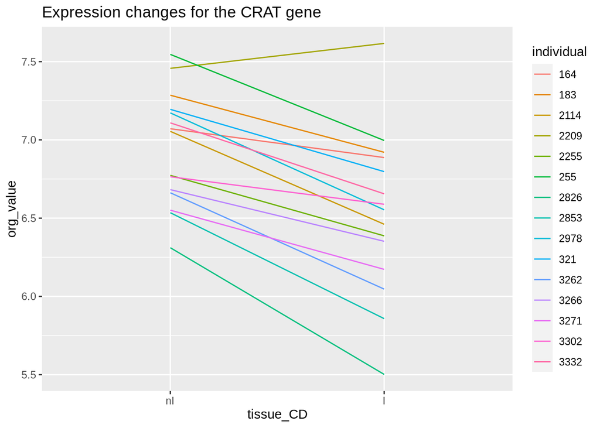

```r
tissue_CD <- tissue[disease == "CD"]
crat_expr <- Biobase::exprs(palmieri_final)["8164535", disease == "CD"]
crat_data <- as.data.frame(crat_expr)
colnames(crat_data)[1] <- "org_value"
crat_data <- mutate(crat_data, individual = i_CD, tissue_CD)

crat_data$tissue_CD <- factor(crat_data$tissue_CD, levels = c("nI", "I"))

ggplot(data = crat_data, aes(x = tissue_CD, y = org_value,
                             group = individual, color = individual)) +
      geom_line() +
      ggtitle("Expression changes for the CRAT gene")
```

```r
crat_coef <- lmFit(palmieri_final[,disease == "CD"],
                design = design_palmieri_CD)$coefficients["8164535",]

crat_coef
```

```
##           I          nI     i_CD183    i_CD2114    i_CD2209    i_CD2255
##  6.76669153  7.19172541  0.12382334 -0.22145266  0.55758621 -0.39905066
##     i_CD255    i_CD2826    i_CD2853    i_CD2978     i_CD321    i_CD3262
##  0.29203533 -1.07285119 -0.78285209 -0.11633433  0.01691936 -0.62480359
##    i_CD3266    i_CD3271    i_CD3302    i_CD3332
## -0.46209081 -0.61731571 -0.30256853 -0.09708624
```

```r
crat_fitted <- design_palmieri_CD %*% crat_coef
rownames(crat_fitted) <- names(crat_expr)
colnames(crat_fitted) <- "fitted_value"

crat_fitted
```

```
##             fitted_value
## 164_I_.CEL      7.191725
## 164_II.CEL      6.766692
## 183_I.CEL       7.315549
## 183_II.CEL      6.890515
## 2114_I.CEL      6.970273
## 2114_II.CEL     6.545239
## 2209_A.CEL      7.749312
## 2209_B.CEL      7.324278
## 2255_I.CEL      6.792675
## 2255_II.CEL     6.367641
## 255_I.CEL       7.483761
## 255_II.CEL      7.058727
## 2826_I.CEL      6.118874
## 2826_II.CEL     5.693840
## 2853_I.CEL      6.408873
## 2853_II.CEL     5.983839
## 2978_I.CEL      7.075391
## 2978_II.CEL     6.650357
## 321_I.CEL       7.208645
## 321_II.CEL      6.783611
## 3262_I.CEL      6.566922
## 3262_II.CEL     6.141888
## 3266_I.CEL      6.729635
## 3266_II.CEL     6.304601
## 3271_I.CEL      6.574410
## 3271_II.CEL     6.149376
## 3302_I.CEL      6.889157
## 3302_II.CEL     6.464123
## 3332_I.CEL      7.094639
## 3332_II.CEL     6.669605
```

```r
crat_coef <- lmFit(palmieri_final[,disease == "CD"],
                design = design_palmieri_CD)$coefficients["8164535",]

crat_coef
```

```
##           I          nI     i_CD183    i_CD2114    i_CD2209    i_CD2255
##  6.76669153  7.19172541  0.12382334 -0.22145266  0.55758621 -0.39905066
##     i_CD255    i_CD2826    i_CD2853    i_CD2978     i_CD321    i_CD3262
##  0.29203533 -1.07285119 -0.78285209 -0.11633433  0.01691936 -0.62480359
##    i_CD3266    i_CD3271    i_CD3302    i_CD3332
## -0.46209081 -0.61731571 -0.30256853 -0.09708624
```

```r
crat_fitted <- design_palmieri_CD %*% crat_coef
rownames(crat_fitted) <- names(crat_expr)
colnames(crat_fitted) <- "fitted_value"

crat_fitted
```

```
##             fitted_value
## 164_I_.CEL      7.191725
## 164_II.CEL      6.766692
## 183_I.CEL       7.315549
## 183_II.CEL      6.890515
## 2114_I.CEL      6.970273
## 2114_II.CEL     6.545239
## 2209_A.CEL      7.749312
## 2209_B.CEL      7.324278
## 2255_I.CEL      6.792675
## 2255_II.CEL     6.367641
## 255_I.CEL       7.483761
## 255_II.CEL      7.058727
## 2826_I.CEL      6.118874
## 2826_II.CEL     5.693840
## 2853_I.CEL      6.408873
## 2853_II.CEL     5.983839
## 2978_I.CEL      7.075391
## 2978_II.CEL     6.650357
## 321_I.CEL       7.208645
## 321_II.CEL      6.783611
## 3262_I.CEL      6.566922
## 3262_II.CEL     6.141888
## 3266_I.CEL      6.729635
## 3266_II.CEL     6.304601
## 3271_I.CEL      6.574410
## 3271_II.CEL     6.149376
## 3302_I.CEL      6.889157
## 3302_II.CEL     6.464123
## 3332_I.CEL      7.094639
## 3332_II.CEL     6.669605
```

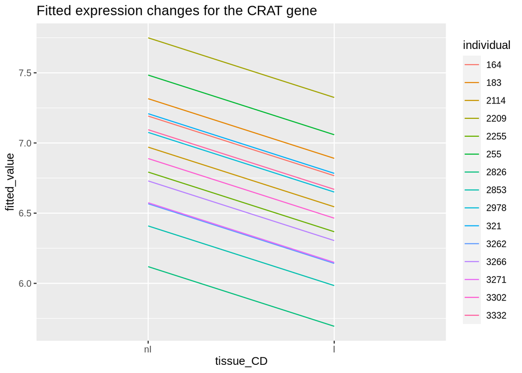

```r
crat_data$fitted_value <- crat_fitted

ggplot(data = crat_data, aes(x = tissue_CD, y = fitted_value,
                             group = individual, color = individual)) +
      geom_line() +
      ggtitle("Fitted expression changes for the CRAT gene")
```

**DGE of the CRAT gene**

```r
crat_noninflamed <- na.exclude(crat_data$org_value[tissue == "nI"])
crat_inflamed <- na.exclude(crat_data$org_value[tissue == "I"])
res_t <- t.test(crat_noninflamed ,crat_inflamed , paired = TRUE)
res_t
```

```
##
##  Paired t-test
##
## data:  crat_noninflamed and crat_inflamed
## t = 6.8493, df = 14, p-value = 7.943e-06
## alternative hypothesis: true difference in means is not equal to 0
## 95 percent confidence interval:
##  0.2919389 0.5581289
## sample estimates:
## mean of the differences
##               0.4250339
```

### Hypothesis Testing

```r
contrast_matrix_CD <- makeContrasts(I-nI, levels = design_palmieri_CD)

palmieri_fit_CD <- eBayes(contrasts.fit(lmFit(palmieri_final[,disease == "CD"],
                                design = design_palmieri_CD),
                                contrast_matrix_CD))

contrast_matrix_UC <- makeContrasts(I-nI, levels = design_palmieri_UC)

palmieri_fit_UC <- eBayes(contrasts.fit(lmFit(palmieri_final[,disease == "UC"],
                                design = design_palmieri_UC),
                                contrast_matrix_UC))
```

### Extracting Results

```r
table_CD <- topTable(palmieri_fit_CD, number = Inf)
head(table_CD)
```

```
##         PROBEID  SYMBOL                            GENENAME      logFC  AveExpr
## 7928695 7928695  PRXL2A               peroxiredoxin like 2A -0.5989663 7.739356
## 8123695 8123695    ECI2         enoyl-CoA delta isomerase 2 -0.4855473 6.876406
## 8164535 8164535    CRAT       carnitine O-acetyltransferase -0.4250339 6.732139
## 8009746 8009746 SLC16A5   solute carrier family 16 member 5 -0.5182389 5.561874
## 7952249 7952249    USP2      ubiquitin specific peptidase 2 -0.8484355 5.605752
## 8105348 8105348    GPX8 glutathione peroxidase 8 (putative)  0.8311803 5.301460
##                 t      P.Value  adj.P.Val        B
## 7928695 -7.058499 1.382580e-06 0.02091702 5.305138
## 8123695 -6.316810 5.905636e-06 0.02091702 4.027286
## 8164535 -6.229728 7.037386e-06 0.02091702 3.871360
## 8009746 -6.206053 7.382237e-06 0.02091702 3.828759
## 7952249 -6.203407 7.421843e-06 0.02091702 3.823993
## 8105348  6.074304 9.647041e-06 0.02091702 3.590060
```

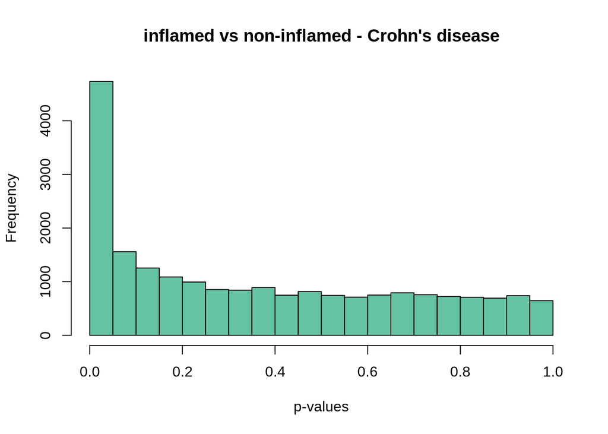

```r
hist(table_CD$P.Value, col = brewer.pal(3, name = "Set2")[1],
     main = "inflamed vs non-inflamed - Crohn's disease", xlab = "p-values")
```

```r
table_UC <- topTable(palmieri_fit_UC, number = Inf)
head(table_UC)
```

```
##         PROBEID  SYMBOL                            GENENAME      logFC  AveExpr
## 8003875 8003875   SPNS2          sphingolipid transporter 2  0.7411995 6.477863
## 8082012 8082012 SLC15A2   solute carrier family 15 member 2  0.8061024 5.318832
## 7952290 7952290  TRIM29      tripartite motif containing 29  1.0140391 5.855191
## 7961693 7961693    LDHB             lactate dehydrogenase B  0.3967609 9.534362
## 8072015 8072015    GRK3 G protein-coupled receptor kinase 3  0.4713293 5.583582
## 8096070 8096070    BMP3        bone morphogenetic protein 3 -1.6961496 6.419944
##                 t      P.Value   adj.P.Val        B
## 8003875  7.800864 4.548958e-07 0.003983161 6.441517
## 8082012  7.743820 5.028316e-07 0.003983161 6.352358
## 7952290  7.482438 8.001717e-07 0.003983161 5.937252
## 7961693  7.401399 9.258508e-07 0.003983161 5.806348
## 8072015  7.308065 1.096440e-06 0.003983161 5.654285
## 8096070 -7.288929 1.135289e-06 0.003983161 5.622935
```

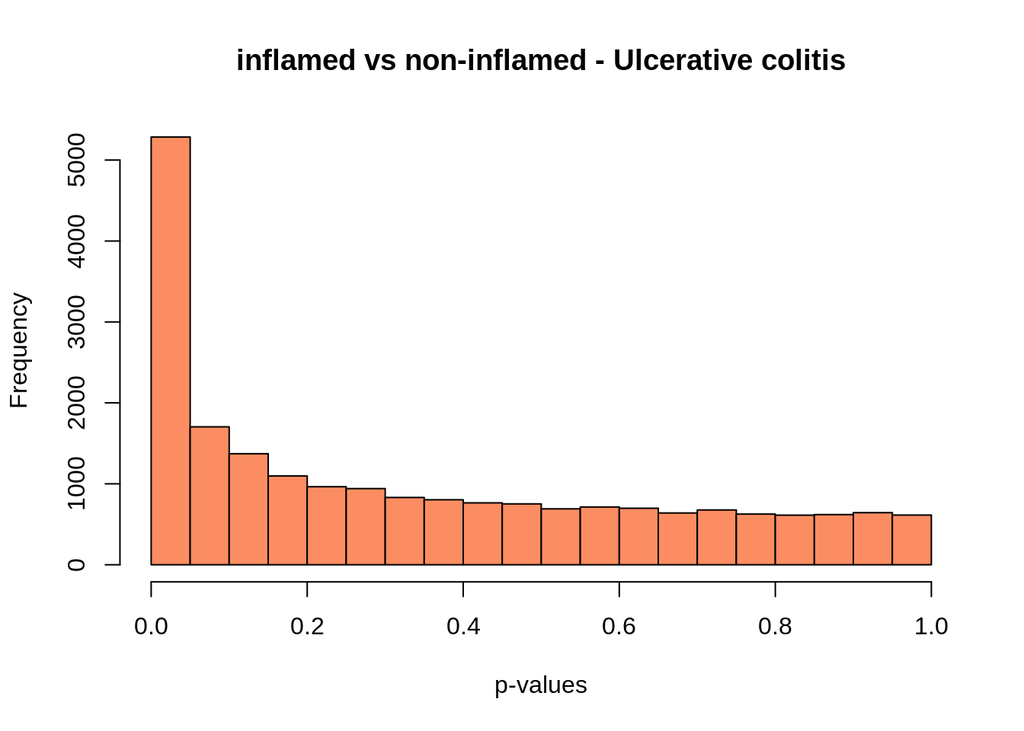

```r
hist(table_UC$P.Value, col = brewer.pal(3, name = "Set2")[2],
     main = "inflamed vs non-inflamed - Ulcerative colitis", xlab = "p-values")
```

### Mtiple testing FDR, Results comparison

```r
nrow(subset(table_UC, P.Value < 0.001))
```

```
## [1] 947
```

```r
tail(subset(table_UC, P.Value < 0.001))
```

```
##         PROBEID   SYMBOL
## 7915640 7915640   EIF2B3
## 7894577 7894577     <NA>
## 7897877 7897877 TNFRSF1B
## 8142671 8142671     WASL
## 7941946 7941946   NDUFV1
## 8140371 8140371 TMEM120A
##                                                          GENENAME      logFC
## 7915640 eukaryotic translation initiation factor 2B subunit gamma  0.2795400
## 7894577                                                      <NA>  0.4047877
## 7897877                        TNF receptor superfamily member 1B  0.3563641
## 8142671               WASP like actin nucleation promoting factor -0.4280742
## 7941946            NADH:ubiquinone oxidoreductase core subunit V1 -0.3831539
## 8140371                                transmembrane protein 120A -0.3657071
##          AveExpr         t      P.Value  adj.P.Val          B
## 7915640 6.271488  3.957208 0.0009864026 0.02204327 -0.6472671
## 7894577 5.598104  3.956089 0.0009888193 0.02205787 -0.6495592
## 7897877 6.655893  3.955760 0.0009895331 0.02205787 -0.6502352
## 8142671 7.906682 -3.955452 0.0009901993 0.02205787 -0.6508655
## 7941946 8.867050 -3.952226 0.0009972104 0.02219057 -0.6574743
## 8140371 6.519433 -3.951571 0.0009986393 0.02219890 -0.6588155
```

```r
fpath <- system.file("extdata", "palmieri_DE_res.xlsx", package = "maEndToEnd")
palmieri_DE_res <- sapply(1:4, function(i) read.xlsx(cols = 1, fpath,
                                                     sheet = i, startRow = 4))

names(palmieri_DE_res) <- c("CD_UP", "CD_DOWN", "UC_UP", "UC_DOWN")
palmieri_DE_res <- lapply(palmieri_DE_res, as.character)
paper_DE_genes_CD <- Reduce("c", palmieri_DE_res[1:2])
paper_DE_genes_UC <- Reduce("c", palmieri_DE_res[3:4])

overlap_CD <- length(intersect(subset(table_CD, P.Value < 0.001)$SYMBOL,
                               paper_DE_genes_CD)) / length(paper_DE_genes_CD)


overlap_UC <- length(intersect(subset(table_UC, P.Value < 0.001)$SYMBOL,
                               paper_DE_genes_UC)) / length(paper_DE_genes_UC)
overlap_CD
```

```
## [1] 0.6409396
```

### Volcano Plot and Results Visualization

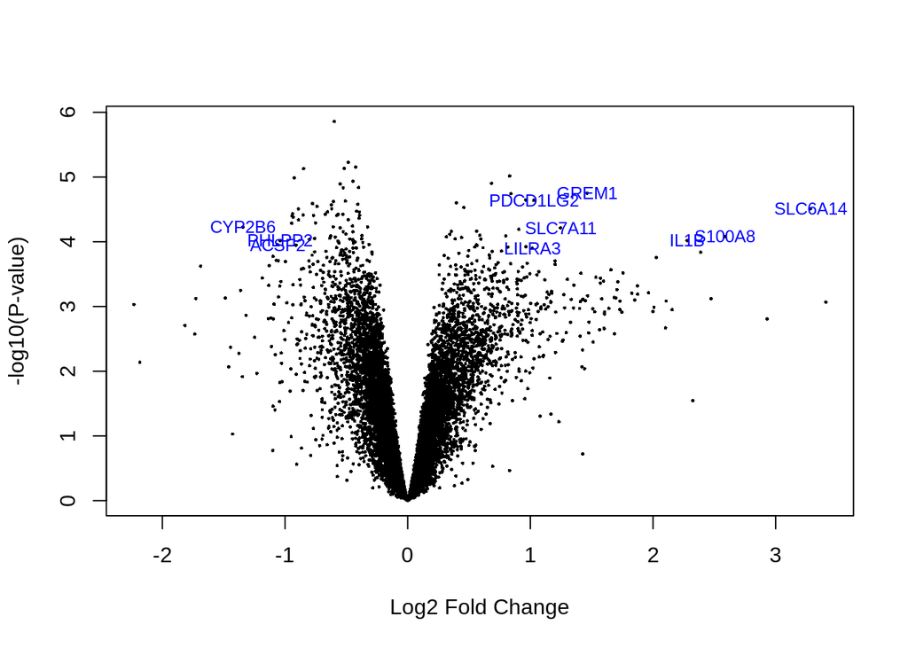

```r
volcano_names <- ifelse(abs(palmieri_fit_CD$coefficients)>=1,
                        palmieri_fit_CD$genes$SYMBOL, NA)


volcanoplot(palmieri_fit_CD, coef = 1L, style = "p-value", highlight = 100,
            names = volcano_names,
            xlab = "Log2 Fold Change", ylab = NULL, pch=16, cex=0.35)
```

## Gene Ontology Based Enrichment Analysis

```r
DE_genes_CD <- subset(table_CD, adj.P.Val < 0.1)$PROBEID
```

```r
back_genes_idx <- genefilter::genefinder(palmieri_final,
                                        as.character(DE_genes_CD),
                                        method = "manhattan", scale = "none")
back_genes_idx <- sapply(back_genes_idx, function(x)x$indices)
```

```r
back_genes <- featureNames(palmieri_final)[back_genes_idx]
back_genes <- setdiff(back_genes, DE_genes_CD)


intersect(back_genes, DE_genes_CD)
```

```
## character(0)
```

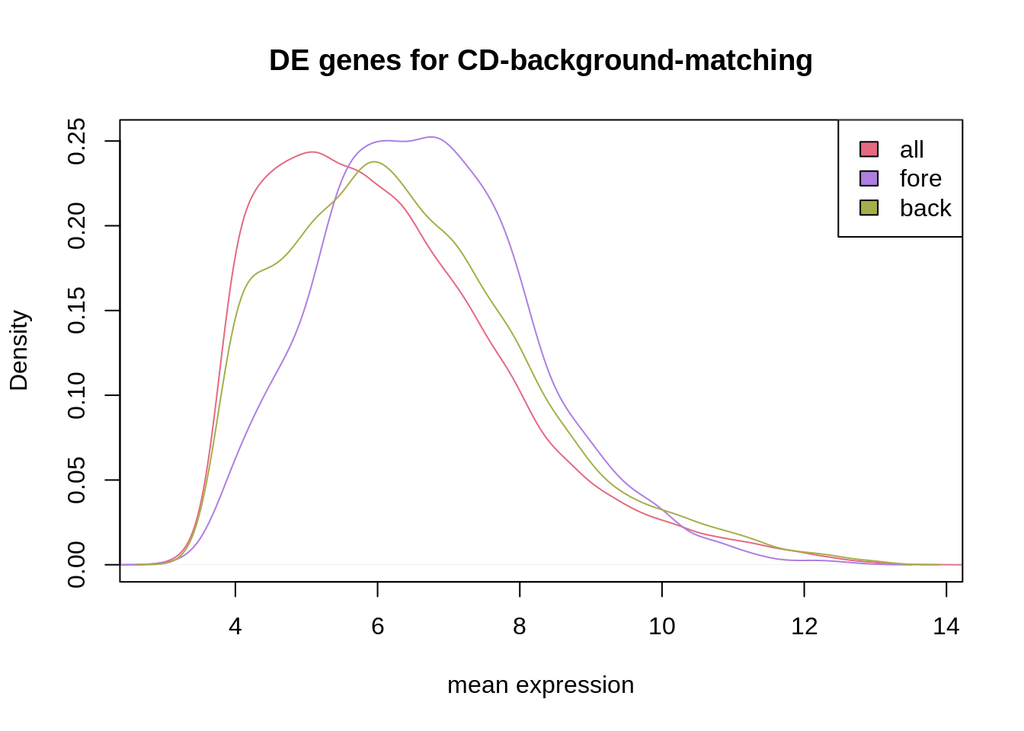

```r
multidensity(list(
        all = table_CD[,"AveExpr"] ,
        fore = table_CD[DE_genes_CD , "AveExpr"],
        back = table_CD[rownames(table_CD) %in% back_genes, "AveExpr"]),
        col = c("#e46981", "#ae7ee2", "#a7ad4a"),
     xlab = "mean expression",
   main = "DE genes for CD-background-matching")
```

### topGO

```r
gene_IDs <- rownames(table_CD)
in_universe <- gene_IDs %in% c(DE_genes_CD, back_genes)
in_selection <- gene_IDs %in% DE_genes_CD

all_genes <- in_selection[in_universe]
all_genes <- factor(as.integer(in_selection[in_universe]))
names(all_genes) <- gene_IDs[in_universe]
```

```r
top_GO_data <- new("topGOdata", ontology = "BP", allGenes = all_genes,
 nodeSize = 10, annot = annFUN.db, affyLib = "hugene10sttranscriptcluster.db")
```

```
##
## Building most specific GOs .....
```

```
##  ( 10434 GO terms found. )
```

```
##
## Build GO DAG topology ..........
```

```
##  ( 14482 GO terms and 34212 relations. )
```

```
##
## Annotating nodes ...............
```

```
##  ( 9553 genes annotated to the GO terms. )
```

```r
result_top_GO_elim <-
  runTest(top_GO_data, algorithm = "elim", statistic = "Fisher")
```

```
##
##           -- Elim Algorithm --
##
##       the algorithm is scoring 5455 nontrivial nodes
##       parameters:
##           test statistic: fisher
##           cutOff: 0.01
```

```
##
##   Level 19:  1 nodes to be scored    (0 eliminated genes)
```

```
##
##   Level 18:  1 nodes to be scored    (0 eliminated genes)
```

```
##
##   Level 17:  7 nodes to be scored    (0 eliminated genes)
```

```
##
##   Level 16:  17 nodes to be scored   (16 eliminated genes)
```

```
##
##   Level 15:  39 nodes to be scored   (16 eliminated genes)
```

```
##
##   Level 14:  80 nodes to be scored   (46 eliminated genes)
```

```
##
##   Level 13:  146 nodes to be scored  (199 eliminated genes)
```

```
##
##   Level 12:  240 nodes to be scored  (584 eliminated genes)
```

```
##
##   Level 11:  403 nodes to be scored  (766 eliminated genes)
```

```
##
##   Level 10:  626 nodes to be scored  (1423 eliminated genes)
```

```
##
##   Level 9:   802 nodes to be scored  (2182 eliminated genes)
```

```
##
##   Level 8:   833 nodes to be scored  (2526 eliminated genes)
```

```
##
##   Level 7:   817 nodes to be scored  (3480 eliminated genes)
```

```
##
##   Level 6:   678 nodes to be scored  (4506 eliminated genes)
```

```
##
##   Level 5:   421 nodes to be scored  (5017 eliminated genes)
```

```
##
##   Level 4:   220 nodes to be scored  (5670 eliminated genes)
```

```
##
##   Level 3:   103 nodes to be scored  (5801 eliminated genes)
```

```
##
##   Level 2:   20 nodes to be scored   (6023 eliminated genes)
```

```
##
##   Level 1:   1 nodes to be scored    (6023 eliminated genes)
```

```r
result_top_GO_classic <-
  runTest(top_GO_data, algorithm = "classic", statistic = "Fisher")
```

```
##
##           -- Classic Algorithm --
##
##       the algorithm is scoring 5455 nontrivial nodes
##       parameters:
##           test statistic: fisher
```

```r
res_top_GO <- GenTable(top_GO_data, Fisher.elim = result_top_GO_elim,
        Fisher.classic = result_top_GO_classic,
        orderBy = "Fisher.elim" , topNodes = 100)

genes_top_GO <- printGenes(top_GO_data, whichTerms = res_top_GO$GO.ID,
    chip = "hugene10sttranscriptcluster.db", geneCutOff = 1000)

res_top_GO$sig_genes <- sapply(genes_top_GO, function(x){
                str_c(paste0(x[x$'raw p-value' == 2, "Symbol.id"],";"),
                      collapse = "")
    })

head(res_top_GO[,1:8], 20)
```

```
##         GO.ID                                        Term Annotated Significant
## 1  GO:0030593                       neutrophil chemotaxis        62          40
## 2  GO:0051897 positive regulation of protein kinase B ...       118          57
## 3  GO:0006954                       inflammatory response       451         193
## 4  GO:0001774                  microglial cell activation        39          25
## 5  GO:0006911                    phagocytosis, engulfment        51          29
## 6  GO:0032496              response to lipopolysaccharide       218          95
## 7  GO:0030335       positive regulation of cell migration       356         137
## 8  GO:0030198           extracellular matrix organization       239          99
## 9  GO:0007186 G protein-coupled receptor signaling pat...       432         145
## 10 GO:0050900                         leukocyte migration       303         140
## 11 GO:0048661 positive regulation of smooth muscle cel...        67          36
## 12 GO:0014068 positive regulation of phosphatidylinosi...        64          31
## 13 GO:0017144                      drug metabolic process       349         142
## 14 GO:0002250                    adaptive immune response       304         118
```

[output cut: 27 more lines]